# Applied Bayesian Analyses in R

Part2

Sven De Maeyer

## Your Turn

Note: I centred both `km4week`and `sp4week` around their mean!

## Results Exercise

*Model1: only an intercept (brms defaults)*

```r
load(file = here(
    "Presentations",
    "MarathonData.RData")
    )

Mod_MT1 <- brm(
  MarathonTimeM ~ 1,
  data = MarathonData,
  backend = "cmdstanr",
  seed = 1975
)
```

[output not shown]

[output cut: 43 more lines]

[output not shown]

## Results Exercise

*Model1: only an intercept (brms defaults)*

```r
summary(Mod_MT1)
```

```
 Family: gaussian
  Links: mu = identity; sigma = identity
Formula: MarathonTimeM ~ 1
   Data: MarathonData (Number of observations: 87)
  Draws: 4 chains, each with iter = 2000; warmup = 1000; thin = 1;
         total post-warmup draws = 4000

Regression Coefficients:
          Estimate Est.Error l-95% CI u-95% CI Rhat Bulk_ESS Tail_ESS
Intercept   199.12      2.42   194.38   203.76 1.00     2903     2125

Further Distributional Parameters:
      Estimate Est.Error l-95% CI u-95% CI Rhat Bulk_ESS Tail_ESS
sigma    22.84      1.73    19.72    26.39 1.00     3314     2946

Draws were sampled using sample(hmc). For each parameter, Bulk_ESS
and Tail_ESS are effective sample size measures, and Rhat is the potential
scale reduction factor on split chains (at convergence, Rhat = 1).
```

## Results Exercise

*Model1: only an intercept (brms defaults)*

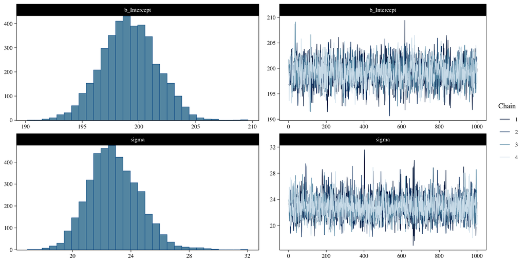

```r
plot(Mod_MT1)
```

## Results Exercise

*Model2: add the effect of* `km4week` *and* `sp4week`

```r
Mod_MT2 <- brm(
  MarathonTimeM ~ 1 + km4week + sp4week,
  data = MarathonData,
  backend = "cmdstanr",
  seed = 1975
)
```

[output not shown]

[output cut: 43 more lines]

[output not shown]

## Results Exercise

*Model2: add the effect of* `km4week` *and* `sp4week`

```r
summary(Mod_MT2)
```

```
 Family: gaussian
  Links: mu = identity; sigma = identity
Formula: MarathonTimeM ~ 1 + km4week + sp4week
   Data: MarathonData (Number of observations: 87)
  Draws: 4 chains, each with iter = 2000; warmup = 1000; thin = 1;
         total post-warmup draws = 4000

Regression Coefficients:
          Estimate Est.Error l-95% CI u-95% CI Rhat Bulk_ESS Tail_ESS
Intercept   199.20      1.50   196.28   202.15 1.00     3852     2838
km4week      -0.42      0.06    -0.53    -0.31 1.00     4189     3157
sp4week      -9.98      1.30   -12.46    -7.50 1.00     4402     3263

Further Distributional Parameters:
      Estimate Est.Error l-95% CI u-95% CI Rhat Bulk_ESS Tail_ESS
sigma    13.94      1.09    11.96    16.29 1.00     3991     3236

Draws were sampled using sample(hmc). For each parameter, Bulk_ESS
and Tail_ESS are effective sample size measures, and Rhat is the potential
scale reduction factor on split chains (at convergence, Rhat = 1).
```

## Results Exercise

*Model2: add the effect of* `km4week` *and* `sp4week`

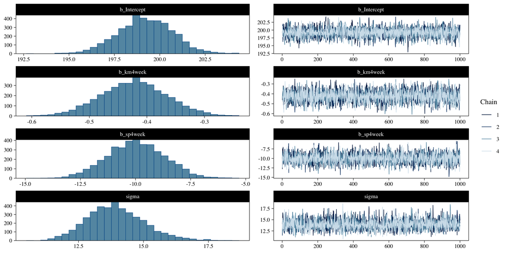

```r
plot(Mod_MT2)
```

## Results Exercise

*Model3: change the brms defaults*

```r
Mod_MT3 <- brm(
  MarathonTimeM ~ 1 + km4week + sp4week,
  data = MarathonData,
  chains = 4,
  iter = 4000,
  cores = 4,
  backend = "cmdstanr",
  seed = 1975
)
```

[output not shown]

[output cut: 123 more lines]

[output not shown]

## Results Exercise

*Model3: change the brms defaults*

```r
summary(Mod_MT3)
```

```
 Family: gaussian
  Links: mu = identity; sigma = identity
Formula: MarathonTimeM ~ 1 + km4week + sp4week
   Data: MarathonData (Number of observations: 87)
  Draws: 4 chains, each with iter = 4000; warmup = 2000; thin = 1;
         total post-warmup draws = 8000

Regression Coefficients:
          Estimate Est.Error l-95% CI u-95% CI Rhat Bulk_ESS Tail_ESS
Intercept   199.15      1.51   196.21   202.14 1.00     8054     5568
km4week      -0.42      0.06    -0.53    -0.31 1.00     8127     5617
sp4week      -9.98      1.29   -12.50    -7.48 1.00     8080     6304

Further Distributional Parameters:
      Estimate Est.Error l-95% CI u-95% CI Rhat Bulk_ESS Tail_ESS
sigma    13.92      1.07    12.02    16.22 1.00     7672     5845

Draws were sampled using sample(hmc). For each parameter, Bulk_ESS
and Tail_ESS are effective sample size measures, and Rhat is the potential
scale reduction factor on split chains (at convergence, Rhat = 1).
```

## Results Exercise

*Model3: change the brms defaults*

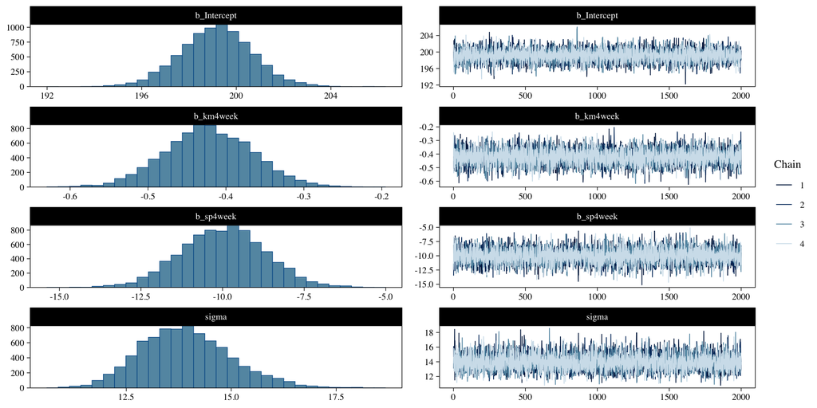

```r
plot(Mod_MT3)
```

## About convergence

[figure not shown]

- $\widehat R$ < 1.015 for each parameter estimate
- at least 4 chains are recommended
- Effective Sample Size (ESS) > 400 to rely on $\widehat R$

## But is it a good model?

Two complementary procedures:

- posterior-predictive check
- compare models with *leave one out cross-validation*

## Posterior-predictive check

A visual check that can be performed with `pp_check()` from `brms`

```r
pp_check(Mod_MT2) + theme_minimal()
```

## Posterior-predictive check

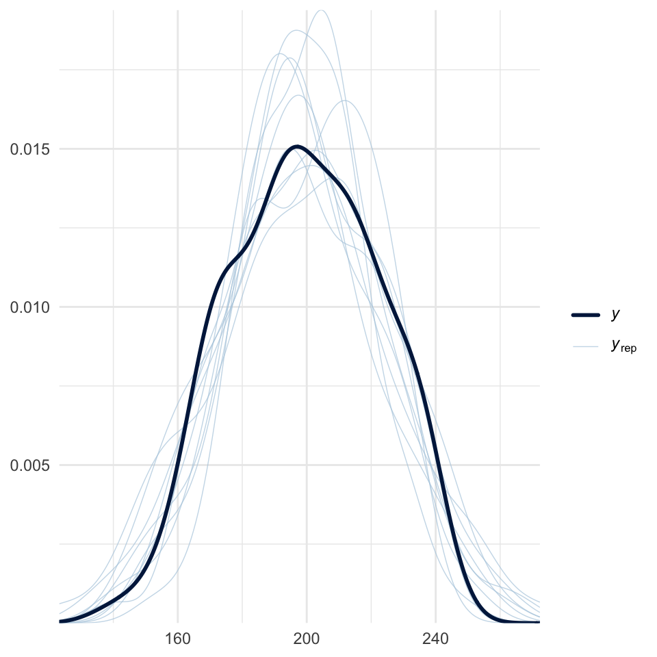

## Model comparison with loo cross-validation

$\sim$ AIC or BIC in Frequentist statistics

$\widehat{elpd}$: “expected log predictive density” (higher $\widehat{elpd}$ implies better model fit without being sensitive for overfitting!)

```r
loo_Mod1 <- loo(MarathonTimes_Mod1)
loo_Mod2 <- loo(MarathonTimes_Mod2)

Comparison<-
  loo_compare(
    loo_Mod1,
    loo_Mod2
    )

print(Comparison, simplify = F)
```

## Model comparison with loo cross-validation

```
                   elpd_diff se_diff elpd_loo se_elpd_loo p_loo  se_p_loo
MarathonTimes_Mod2    0.0       0.0  -356.3     12.0         7.2    4.4
MarathonTimes_Mod1  -39.9      12.6  -396.2      5.3         1.7    0.3
                   looic  se_looic
MarathonTimes_Mod2  712.6   24.0
MarathonTimes_Mod1  792.3   10.6
```

# WAMBS checklist

## When to Worry and How to Avoid Misuse of Bayesian Statistics

by Laurent Smeets and Rens van der Schoot

Before estimating the model:

1. Do you understand the priors?

After estimation before inspecting results:

2. Does the trace-plot exhibit convergence?
3. Does convergence remain after doubling the number of iterations?
4. Does the posterior distribution histogram have enough information?
5. Do the chains exhibit a strong degree of autocorrelation?
6. Do the posterior distributions make substantive sense?

Understanding the exact influence of the priors

7. Do different specification of the multivariate variance priors influence the results?
8. Is there a notable effect of the prior when compared with non-informative priors?
9. Are the results stable from a sensitivity analysis?
10. Is the Bayesian way of interpreting and reporting model results used?

Tutorial source: https://www.rensvandeschoot.com/brms-wambs/ Alternatives exist as well like the BARG framework (Kruschke, J.K. Bayesian Analysis Reporting Guidelines. Nat Hum Behav 5, 1282–1291 (2021). https://doi.org/10.1038/s41562-021-01177-7)

## WAMBS Template to use

- File called WAMBS_workflow_MarathonData.qmd (quarto document)
- [Click here](https://abar-geneva-2024.netlify.app/WAMBS_template/WAMBS_workflow_MarathonData.qmd) for the Quarto version
- Create your own project and project folder
- Copy the template and rename it
- We will go through the different parts in the slide show
- You can apply/adapt the code in the template
- To render the document properly with references, you also need the [references.bib file](https://abar-geneva-2024.netlify.app/WAMBS_template/references.bib)

## Side-path: projects in RStudio and the `here` package

If you do not know how to use Projects in RStudio or the `here` package, these two sources might be helpfull:

Projects: https://youtu.be/MdTtTN8PUqU?si=mmQGlU063EMt86B2

`here` package: https://youtu.be/oh3b3k5uM7E?si=0-heLJXfFVLtTohh

## Preparations for applying it to Marathon model

Packages needed:

```r
library(here)
library(tidyverse)
library(brms)
library(bayesplot)
library(ggmcmc)
library(patchwork)
library(priorsense)
```

## Preparations for applying it to Marathon model

Load the dataset and the model:

```r
load(
  file = here("Presentations", "MarathonData.RData")
)

MarathonTimes_Mod2 <-
  readRDS(file =
            here("Presentations",
              "Output",
              "MarathonTimes_Mod2.RDS")
          )
```

# Focus on the priors before estimation

## Remember: priors come in many disguises

Uninformative/Weakly informative

When objectivity is crucial and you want *let the data speak for itself…*

Informative

When including significant information is crucial

- previously collected data
- results from former research/analyses
- data of another source
- theoretical considerations
- elicitation

## `brms` defaults

- Weakly informative priors
- If dataset is big, impact of priors is minimal
- But, always better to know what you are doing!
- Complex models might run into convergence issues $\rightarrow$ specifying more informative priors might help!

So, how to deviate from the defaults?

## Check priors used by `brms`

Function: `get_prior( )`

Remember our model 2 for Marathon Times:

$$\begin{aligned}
& \text{MarathonTimeM}_i \sim N(\mu,\sigma_e)\\
& \mu = \beta_0 + \beta_1*\text{km4week}_i + \beta_2*\text{sp4week}_i
\end{aligned}$$

```r
get_prior(
  MarathonTimeM ~ 1 + km4week + sp4week,
  data = MarathonData
)
```

## Check priors used by `brms`

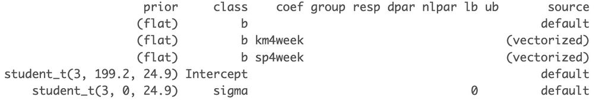

- `prior`: type of prior distribution
- `class`: parameter class (with `b` being population-effects)
- `coef`: name of the coefficient within parameter class
- `group`: grouping factor for group-level parameters (when using mixed effects models)
- `resp` : name of the response variable when using multivariate models
- `lb` & `ub`: lower and upper bound for parameter restriction

## Visualizing priors

The best way to make sense of the priors used is visualizing them!

Many options:

- The Zoo of Distributions https://ben18785.shinyapps.io/distribution-zoo/
- making your own visualizations

See WAMBS template!

There we demonstrate the use of `ggplot2`, `metRology`, `ggtext` and `patchwork` to visualize the priors.

## Visualizing priors

```r
library(metRology)
library(ggplot2)
library(ggtext)
library(patchwork)

# Setting a plotting theme
theme_set(theme_linedraw() +
            theme(text = element_text(family = "Times", size = 8),
                  panel.grid = element_blank(),
                  plot.title = element_markdown())
)

# Generate the plot for the prior of the Intercept (mu)
Prior_mu <- ggplot( ) +
  stat_function(
    fun = dt.scaled,    # We use the dt.scaled function of metRology
    args = list(df = 3, mean = 199.2, sd = 24.9), #
    xlim = c(120,300)
  ) +
  scale_y_continuous(name = "density") +
  labs(title = "Prior for the intercept",
       subtitle = "student_t(3,199.2,24.9)")

# Generate the plot for the prior of the error variance (sigma)
Prior_sigma <- ggplot( ) +
  stat_function(
    fun = dt.scaled,    # We use the dt.scaled function of metRology
    args = list(df = 3, mean = 0, sd = 24.9), #
    xlim = c(0,6)
  ) +
  scale_y_continuous(name = "density") +
  labs(title = "Prior for the residual variance",
       subtitle = "student_t(3,0,24.9)")

# Generate the plot for the prior of the effects of independent variables
Prior_betas <- ggplot( ) +
  stat_function(
    fun = dnorm,    # We use the normal distribution
    args = list(mean = 0, sd = 10), #
    xlim = c(-20,20)
  ) +
  scale_y_continuous(name = "density") +
  labs(title = "Prior for the effects of independent variables",
       subtitle = "N(0,10)")

Prior_mu + Prior_sigma + Prior_betas +
  plot_layout(ncol = 3)
```

## Visualizing priors

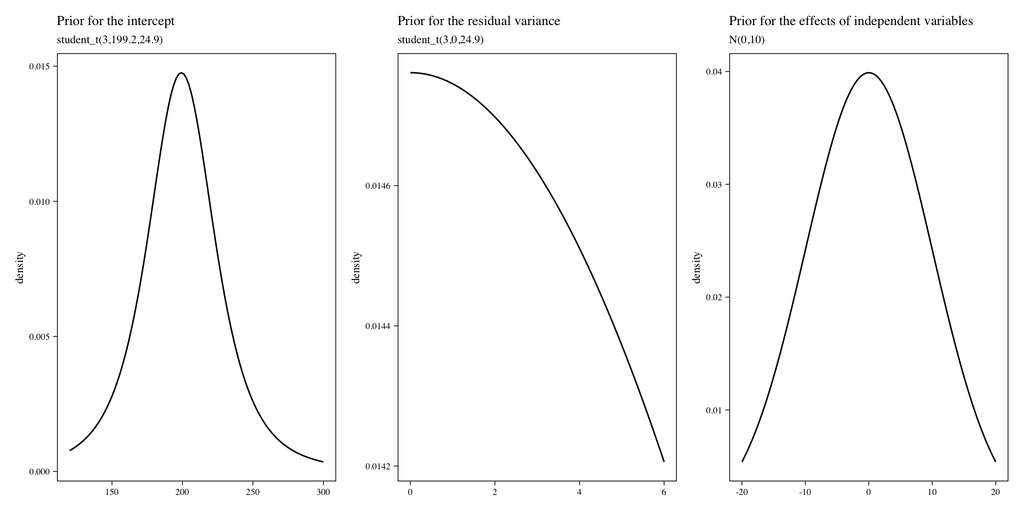

Probability density plots for the different priors used in the example model

## Understanding priors… another example

Experimental study (pretest - posttest design) with 3 conditions:

- control group;
- experimental group 1;
- experimental group 2.

Model:

$$\begin{aligned}
& Posttest_{i} \sim N(\mu,\sigma_{e_{i}})\\
& \mu = \beta_0 + \beta_1*\text{Pretest}_{i} + \beta_2*\text{Exp_cond1}_{i} + \beta_3*\text{Exp_cond2}_{i}
\end{aligned}$$

Our job: coming up with priors that reflect that we expect both conditions to have a positive effect (hypothesis based on literature) and no indications that one experimental condition will outperform the other.

## Understanding priors… another example

- Assuming pre- and posttest scores are standardized
- Assuming no increase between pre- and posttest in control condition

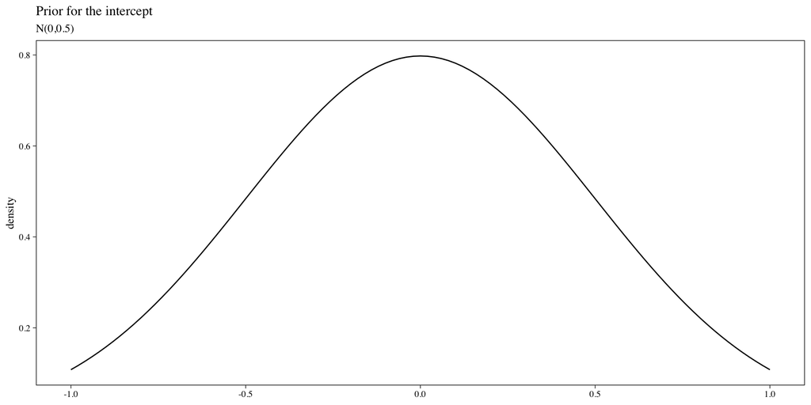

## Understanding priors… another example

- Assuming a strong correlation between pre- and posttest

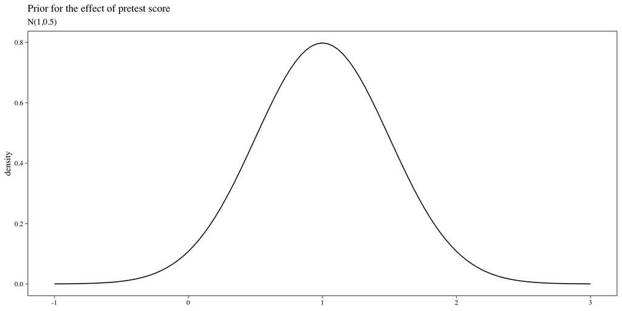

## Understanding priors… another example

- Assuming a small effect of experimental conditions
- No difference between both experimental conditions

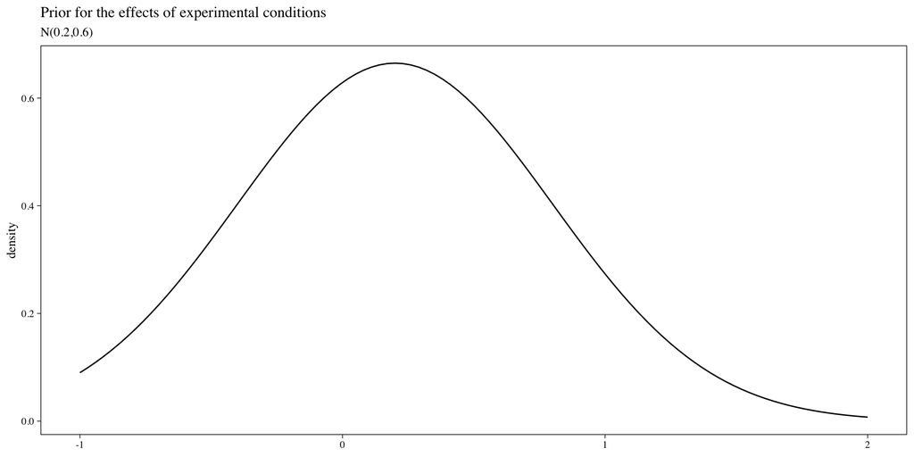

Remember Cohen’s d: 0.2 = small effect size; 0.5 = medium effect size; 0.8 or higher = large effect size

## Setting custom priors in `brms`

Setting our custom priors can be done with `set_prior( )` command

E.g., change the priors for the beta’s (effects of `km4week` and `sp4week`):

```r
Custom_priors <-
  c(
    set_prior(
      "normal(0,10)",
      class = "b",
      coef = "km4week"),
    set_prior(
      "normal(0,10)",
      class = "b",
      coef = "sp4week")
    )
```

## Prior Predictive Check

Did you set sensible priors?

- Simulate data based on the model and the priors
- Visualize the simulated data and compare with real data
- Check if the plot shows impossible simulated datasets

## Prior Predictive Check in `brms`

Step 1: Fit the model with custom priors with option `sample_prior="only"`

```r
Fit_Model_priors <-
  brm(
    MarathonTimeM ~ 1 + km4week + sp4week,
    data = MarathonData,
    prior = Custom_priors,
    backend = "cmdstanr",
    cores = 4,
    sample_prior = "only"
    )
```

## Prior Predictive Check in `brms`

Step 2: visualize the data with the `pp_check( )` function

```r
set.seed(1975)

pp_check(
  Fit_Model_priors,
  ndraws = 300) # number of simulated datasets you wish for
```

## Prior Predictive Check in `brms`

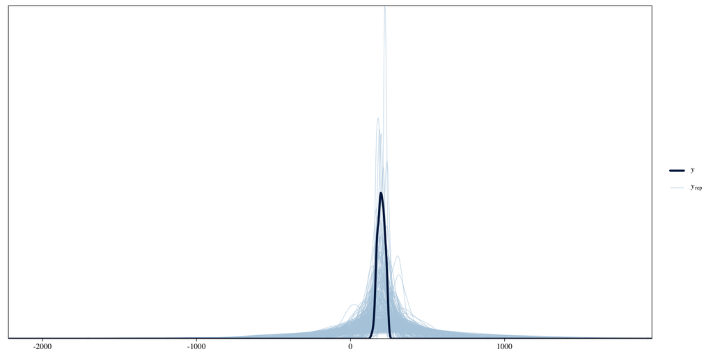

## Check some summary statistics

- How are summary statistics of simulated datasets (e.g., median, min, max, …) distributed over the datasets?
- How does that compare to our real data?
- Use `type = "stat"` argument within `pp_check()`

```r
pp_check(Fit_Model_priors,
         type = "stat",
         stat = "median")
```

## Check some summary statistics

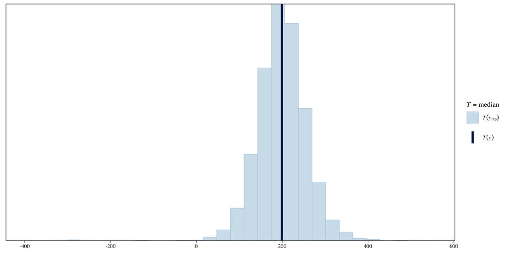

## Your Turn

- Your data and model
- Perform a prior predictive check
- If necessary re-think your priors and check again

# Focus on convergence of the model (before interpreting the model!)

## Does the trace-plot exhibits convergence?

Create custom trace-plots (aka caterpillar plots) with `ggs( )` function from `ggmcmc` package

```r
Model_chains <- ggs(MarathonTimes_Mod2)

Model_chains %>%
  filter(Parameter %in% c(
          "b_Intercept",
          "b_km4week",
          "b_sp4week",
          "sigma"
          )
  ) %>%
  ggplot(aes(
    x   = Iteration,
    y   = value,
    col = as.factor(Chain)))+
  geom_line() +
  facet_grid(Parameter ~ .,
             scale  = 'free_y',
             switch = 'y') +
  labs(title = "Caterpillar Plots for the parameters",
       col   = "Chains")
```

## Does the trace-plot exhibits convergence?

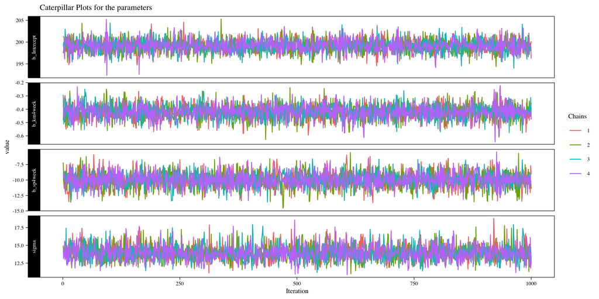

Caterpillar plots for the parameters in the model

## Does convergence remain after doubling the number of iterations?

Re-fit the model with more iterations

Check trace-plots again

**Warning**

First consider the need to do this! If you have a complex model that already took a long time to run, this check will take at least twice as much time…

## Your Turn

- Your data and model
- Do the first checks on the model convergence

## R-hat statistics

Sampling of parameters done by:

- multiple chains
- multiple iterations within chains

If variance between chains is big $\rightarrow$ NO CONVERGENCE

R-hat ($\widehat{R}$) : compares the between- and within-chain estimates for model parameters

## R-hat statistics

[figure not shown]

- $\widehat{R}$ < 1.015 for each parameter estimate
- at least 4 chains are recommended
- Effective Sample Size (ESS) > 400 to rely on $\widehat{R}$

## R-hat in `brms`

`mcmc_rhat()` function from the `bayesplot` package

```r
mcmc_rhat(
  brms::rhat(MarathonTimes_Mod2),
  size = 3
  )+
  yaxis_text(hjust = 1)  # to print parameter names
```

## R-hat in `brms`

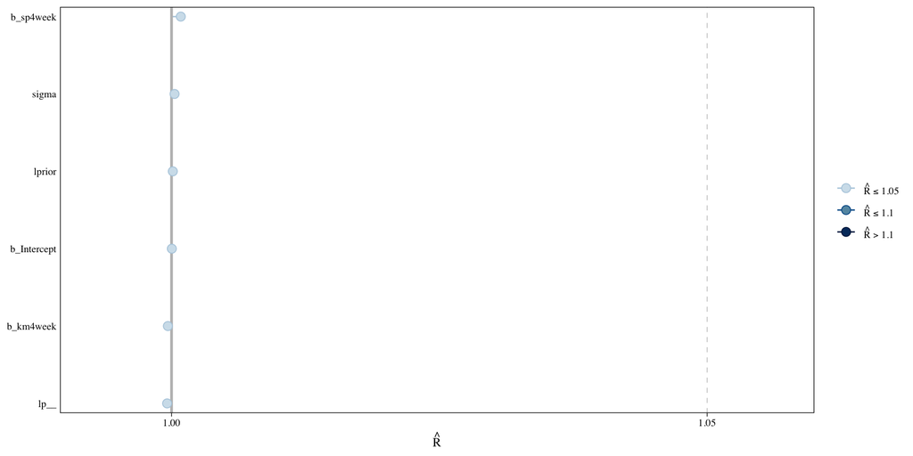

## Your Turn

- Your data and model
- Check the R-hat statistics

## Autocorrelation

- Sampling of parameter values are not independent!
- So there is autocorrelation
- But you don’t want too much impact of autocorrelation
- 2 approaches to check this:
  - ratio of the effective sample size to the total sample size
  - plot degree of autocorrelation

## Ratio effective sample size / total sample size

- Should be higher than 0.1 (Gelman et al., 2013)
- Visualize making use of the `mcmc_neff( )` function from `bayesplot`

```r
mcmc_neff(
  neff_ratio(MarathonTimes_Mod2)
  ) +
  yaxis_text(hjust = 1)  # to print parameter names
```

## Ratio effective sample size / total sample size

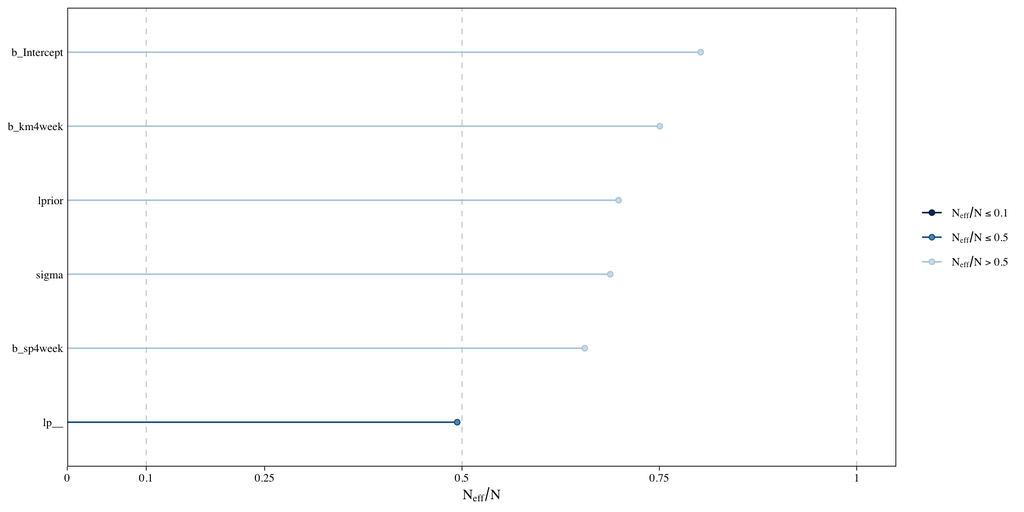

## Plot degree of autocorrelation

- Visualize making use of the `mcmc_acf( )` function

```r
mcmc_acf(
  as.array(MarathonTimes_Mod2),
  regex = "b") # to plot only the parameters starting with b (our beta's)
```

## Plot degree of autocorrelation

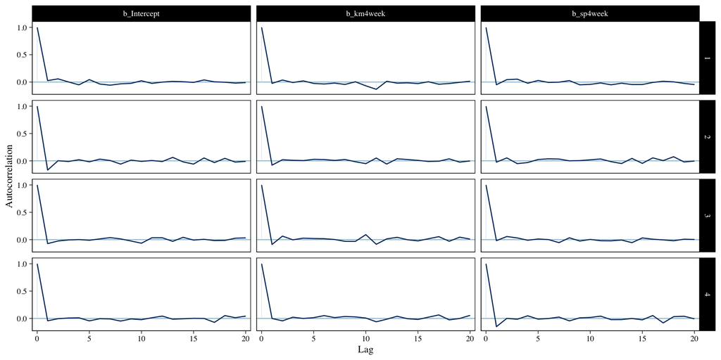

## Your Turn

- Your data and model
- Check the autocorrelation

## Rank order plots

- additional way to assess the convergence of MCMC
- if the algorithm converged, plots of all chains look similar

```r
mcmc_rank_hist(
  MarathonTimes_Mod2,
  regex = "b" # only intercept and beta's
  )
```

## Rank order plots

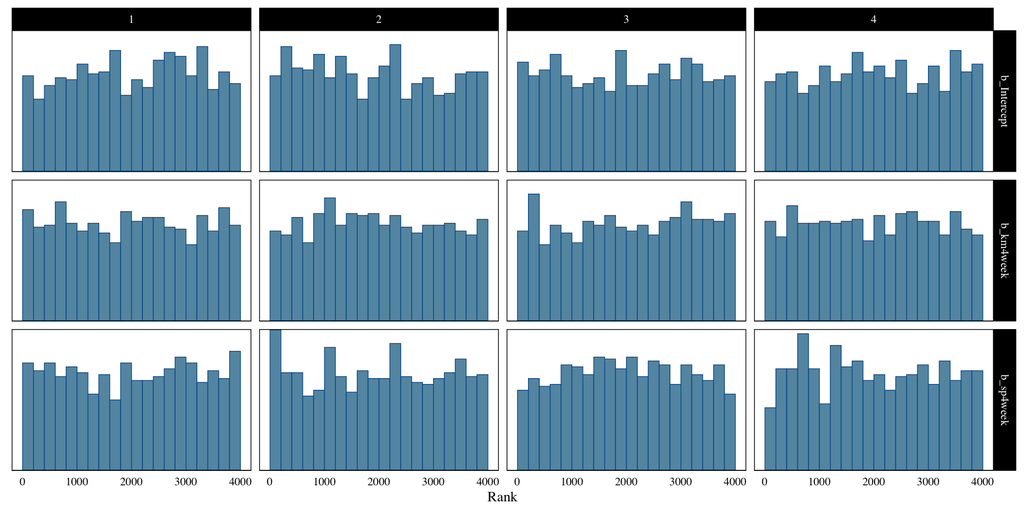

## Your Turn

- Your data and model
- Check the rank order plots

# Focus on the Posterior

## Does the posterior distribution histogram have enough information?

- Histogram of posterior for each parameter
- Have clear peak and sliding slopes

## Plotting the posterior distribution histogram

Step 1: create a new object with ‘draws’ based on the final model

```r
posterior_PD <- as_draws_df(MarathonTimes_Mod2)
```

## Plotting the posterior distribution histogram

Step 2: create histogram making use of that object

```r
post_intercept <-
  posterior_PD %>%
  select(b_Intercept) %>%
  ggplot(aes(x = b_Intercept)) +
  geom_histogram() +
  ggtitle("Intercept")

post_km4week <-
  posterior_PD %>%
  select(b_km4week) %>%
  ggplot(aes(x = b_km4week)) +
  geom_histogram() +
  ggtitle("Beta km4week")

post_sp4week <-
  posterior_PD %>%
  select(b_sp4week) %>%
  ggplot(aes(x = b_sp4week)) +
  geom_histogram() +
  ggtitle("Beta sp4week")
```

## Plotting the posterior distribution histogram

Step 3: print the plot making use of `patchwork` ’s workflow to combine plots

```r
post_intercept + post_km4week + post_sp4week +
  plot_layout(ncol = 3)
```

## Plotting the posterior distribution histogram

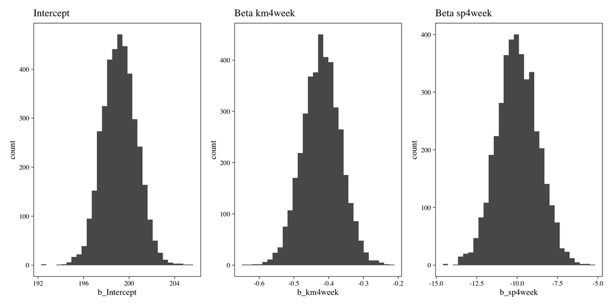

## Posterior Predictive Check

- Generate data based on the posterior probability distribution
- Create plot of distribution of y-values in these simulated datasets
- Overlay with distribution of observed data

using `pp_check()` again, now with our model

```r
pp_check(MarathonTimes_Mod2,
         ndraws = 100)
```

## Posterior Predictive Check

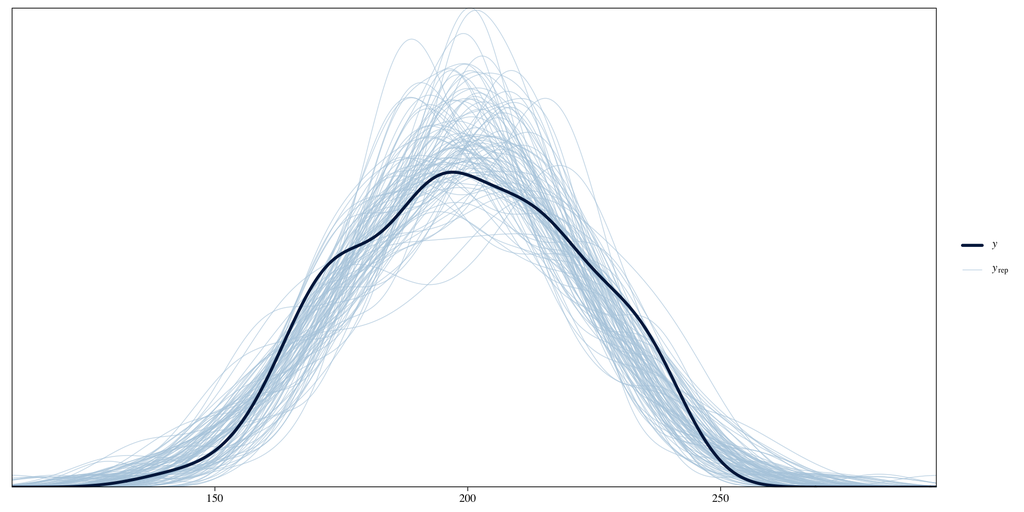

## Posterior Predictive Check

- We can also focus on some summary statistics (like we did with prior predictive checks as well)

```r
pp_check(MarathonTimes_Mod2,
         ndraws = 300,
         type = "stat",
         stat = "median")
```

## Posterior Predictive Check

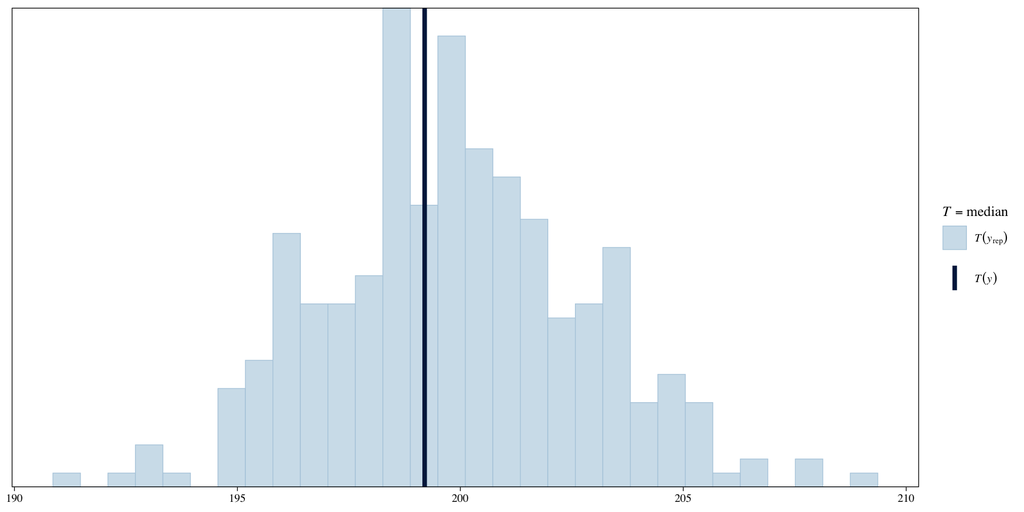

## Your Turn

- Your data and model
- Focus on the posterior and do some checks!

# Prior sensibility analyses

## Why prior sensibility analyses?

- Often we rely on ‘arbitrary’ chosen (default) weakly informative priors
- What is the influence of the prior (and the likelihood) on our results?
- You could ad hoc set new priors and re-run the analyses and compare (a lot of work, without strict sytematical guidelines)
- Semi-automated checks can be done with `priorsense` package

## Using the `priorsense` package

Recently a package dedicated to prior sensibility analyses is launched

```r
# install.packages("remotes")
remotes::install_github("n-kall/priorsense")
```

Key-idea: power-scaling (both prior and likelihood)

background reading:

- https://arxiv.org/pdf/2107.14054.pdf

YouTube talk:

- https://www.youtube.com/watch?v=TBXD3HjcIps&t=920s

## Basic table with indices

First check is done by using the `powerscale_sensitivity( )` function

- column prior contains info on sensibility for prior (should be lower than 0.05)
- column likelihood contains info on sensibility for likelihood (that we want to be high, ‘let our data speak’)
- column diagnosis is a verbalization of potential problem (- if none)

```r
powerscale_sensitivity(MarathonTimes_Mod2)
```

## Basic table with indices

```
Sensitivity based on cjs_dist:
# A tibble: 4 × 4
  variable       prior likelihood diagnosis
  <chr>          <dbl>      <dbl> <chr>
1 b_Intercept 0.000853     0.0851 -
2 b_km4week   0.000512     0.0802 -
3 b_sp4week   0.000370     0.0831 -
4 sigma       0.00571      0.151  -
```

## Visualization of prior sensibility

```r
powerscale_plot_dens(
  powerscale_sequence(
    MarathonTimes_Mod2
    ),
  variable = c(
      "b_Intercept",
      "b_km4week",
      "b_sp4week"
    )
  )
```

## Visualization of prior sensibility

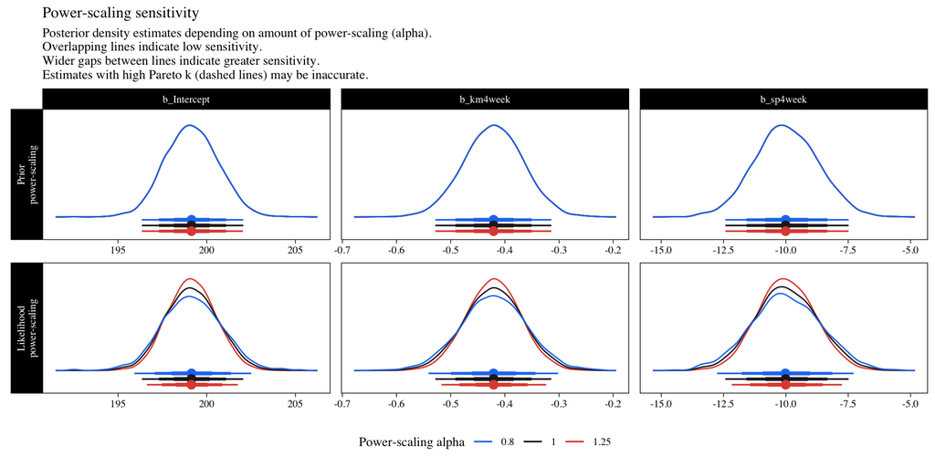

## Visualization of prior sensibility

```r
powerscale_plot_quantities(
  powerscale_sequence(
    MarathonTimes_Mod2
    ),
  variable = c(
      "b_km4week"
      )
  )
```

## Visualization of prior sensibility

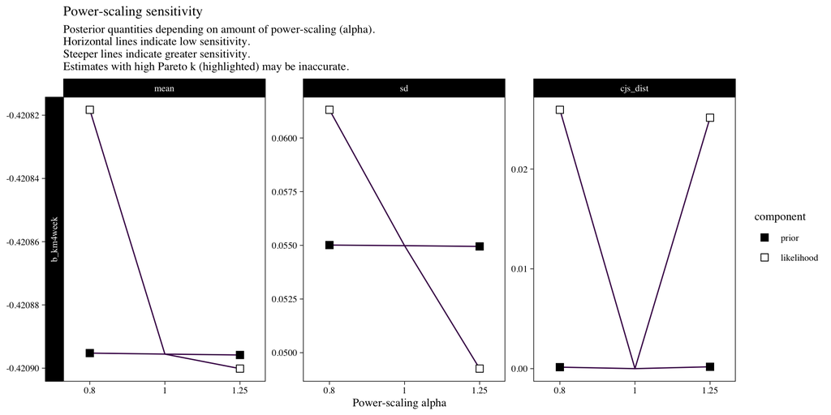

## Your Turn

- Your data and model
- Check the prior sensibility of your results